# Visualization Basics: Histograms & Boxplots

Data visualization helps us quickly understand data patterns, distribution, and outliers.

## Histogram

A **histogram** shows the **distribution of numerical data** using bars.

**Key points:**

- X-axis → Data ranges (bins)
- Y-axis → Frequency
- Shows data distribution and skewness

**Helps identify:**

- Normal, left-skewed, or right-skewed data
- Spread and concentration of values

**Best used for:** Understanding data distribution

## Boxplot (Box-and-Whisker Plot)

A **boxplot** summarizes data using the **five-number summary**:

- Minimum, Q1, Median, Q3, Maximum

**Key points:**

- Box → IQR (Q3 − Q1)
- Line inside box → Median
- Points → Outliers

**Helps identify:**

- Median and spread
- Outliers
- Comparison between datasets

**Best used for:** Outlier detection and comparison

## Histogram vs Boxplot

| Feature | Histogram | Boxplot |
| --- | --- | --- |
| Distribution shape | Yes | No |
| Outliers | No | Yes |
| Comparison | Moderate | Easy |

**Conclusion:** Histograms show how data is distributed, while boxplots summarize data and highlight outliers.

**1. Load a numerical column from a CSV dataset (for example: student scores or fare values).**

```python
import csv
def load_california_numerical(filepath):
    numerical_data = { "median_house_value": [], "median_income":[] }
    with open(filepath, "r", newline="", encoding="utf-8") as f:
        reader = csv.DictReader(f)
        for row in reader:
            house_val = row["median_house_value"]
            income = row["median_income"]
            numerical_data["median_house_value"].append(float(house_val) if house_val != '' else None)
            numerical_data["median_income"].append(float(income) if income != '' else None)
        return numerical_data
data = load_california_numerical("housing.csv")
testdata=load_california_numerical("california_housing_test.csv")
mdn_test_house = testdata["median_house_value"]
# lets us take numerical column median_house_value
mdn_house = data["median_house_value"]

print(mdn_test_house[:20],len(mdn_test_house))
print("")
print(mdn_house[:20],len(mdn_house))
```

```
[344700.0, 176500.0, 270500.0, 330000.0, 81700.0, 67000.0, 67000.0, 166900.0, 194400.0, 164200.0, 125000.0, 58300.0, 252600.0, 231200.0, 222500.0, 153100.0, 181300.0, 137500.0, 300000.0, 414300.0] 3000

[452600.0, 358500.0, 352100.0, 341300.0, 342200.0, 269700.0, 299200.0, 241400.0, 226700.0, 261100.0, 281500.0, 241800.0, 213500.0, 191300.0, 159200.0, 140000.0, 152500.0, 155500.0, 158700.0, 162900.0] 20640
```

**Plot a histogram to visualize the distribution of the selected column. • Choose an appropriate number of bins • Label the x-axis and y-axis**

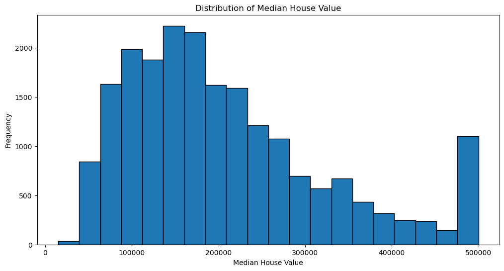

```python
import matplotlib.pyplot as plt

# Remove None values
clean_mdn_house = [x for x in mdn_house if x is not None]

plt.figure(figsize=(12, 6))
plt.hist(clean_mdn_house, bins=20, edgecolor="black")

plt.title("Distribution of Median House Value")
plt.xlabel("Median House Value")
plt.ylabel("Frequency")

plt.show()
```

**3. Plot a density plot (KDE) to understand the smooth distribution of the data.**

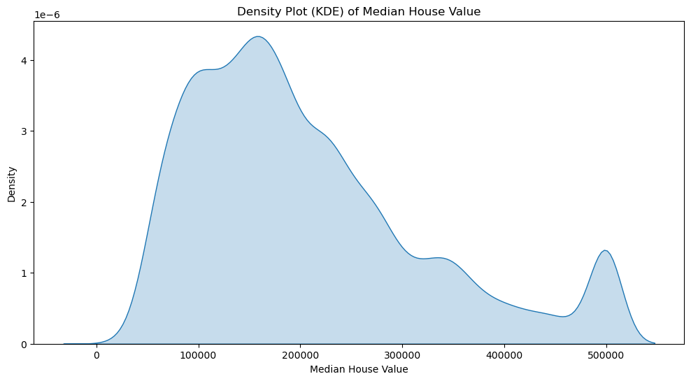

```python
import seaborn as sns
import matplotlib.pyplot as plt

# Remove None values
clean_mdn_house = [x for x in mdn_house if x is not None]

plt.figure(figsize=(12, 6))
sns.kdeplot(clean_mdn_house, fill=True)

plt.title("Density Plot (KDE) of Median House Value")
plt.xlabel("Median House Value")
plt.ylabel("Density")

plt.show()
#The density plot (KDE) visualizes the smooth probability distribution of median house values.
#It helps understand data concentration and skewness without using bins
```

**4. Create a boxplot for the same column to visually identify outliers.**

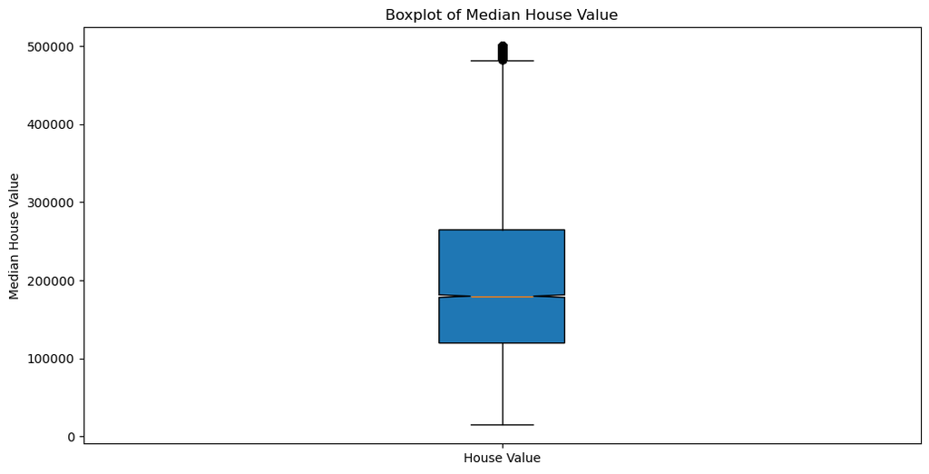

```python
import matplotlib.pyplot as plt

# Remove None values
clean_mdn_house = [x for x in mdn_house if x is not None]

plt.figure(figsize=(12,6))

# Create boxplot
plt.boxplot(clean_mdn_house,
            vert=True,          # vertical boxplot
            patch_artist=True,  # fill color
            notch=True,         # adds median notch
            )

plt.title("Boxplot of Median House Value")
plt.ylabel("Median House Value")
plt.xticks([1], ["House Value"])  # better X-axis label for single column
plt.show()
```

**5. Compare the histogram and density plot and explain (in comments or output text) what each visualization reveals about the data**

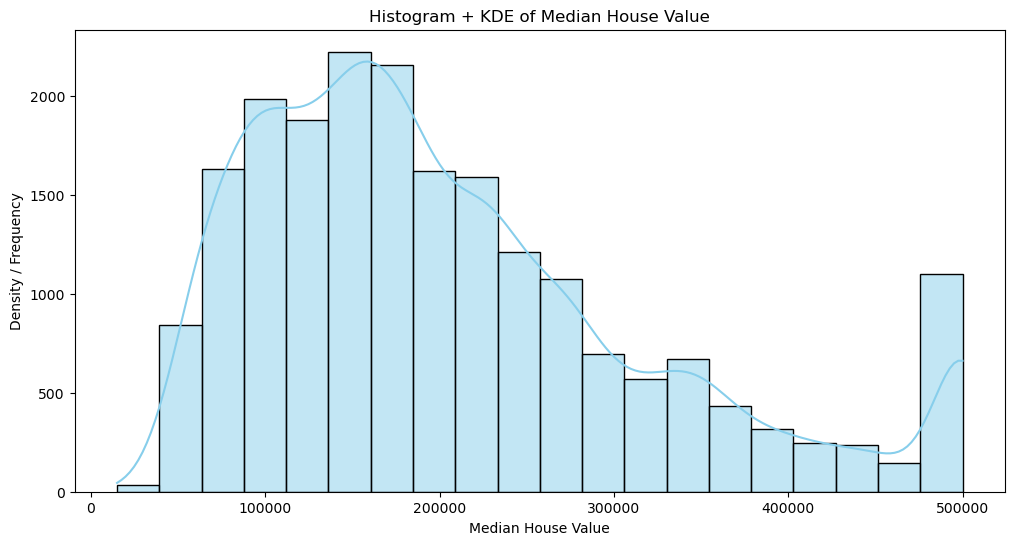

```python
import matplotlib.pyplot as plt
import seaborn as sns

# Clean data
clean_mdn_house = [x for x in mdn_house if x is not None]

plt.figure(figsize=(12, 6))

# Plot histogram with density normalized
sns.histplot(clean_mdn_house, bins=20, color='skyblue', edgecolor='black', kde=True)

plt.title("Histogram + KDE of Median House Value")
plt.xlabel("Median House Value")
plt.ylabel("Density / Frequency")
plt.show()
```

**Histogram:** Displays the actual number of houses within fixed price intervals. It shows a right-skewed distribution, with most properties concentrated in the low to mid price ranges. The sudden spike and cutoff near $500,000 indicates an upper value cap in the dataset, where higher prices are not recorded beyond this limit.

**Density (KDE) plot:** Provides a smoothed representation of the same data, making the overall distribution shape easier to interpret. It clearly confirms the right skewness, reveals multiple peaks that suggest the presence of different housing sub-markets, and makes the price cap near $500,000 more apparent through a sharp rise and drop at the upper end.

**6. Using the boxplot, identify how many outliers are present and print their values.**

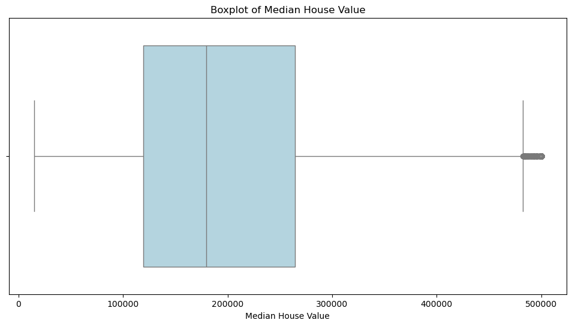

```
Number of outliers: 1071
Outlier values: [500001.0, 483300.0, 500001.0, 489600.0, 500001.0, 500001.0, 500001.0, 500001.0, 500001.0, 500001.0, 500001.0, 500001.0, 500001.0, 500001.0, 500001.0, 494000.0, 500001.0, 500001.0, 500001.0, 500001.0, 500001.0, 500001.0, 500001.0, 500001.0, 500001.0, 500001.0, 500001.0, 499000.0, 500…
```

```python
import matplotlib.pyplot as plt
import seaborn as sns

# Assuming mdn_house is already loaded and cleaned
clean_mdn_house = [x for x in mdn_house if x is not None]

# -------------------------
# 1. Plot Boxplot
# -------------------------
plt.figure(figsize=(12,6))
sns.boxplot(x=clean_mdn_house, color='lightblue', orient='h')
plt.title("Boxplot of Median House Value")
plt.xlabel("Median House Value")
plt.show()

# -------------------------
# 2. Identify Outliers
# -------------------------
# Calculate Q1, Q3, IQR
data_sorted = sorted(clean_mdn_house)
Q1 = data_sorted[int(0.25 * len(data_sorted))]
Q3 = data_sorted[int(0.75 * len(data_sorted))]
IQR = Q3 - Q1

# Outlier boundaries
lower_bound = Q1 - 1.5 * IQR
upper_bound = Q3 + 1.5 * IQR

# Find outliers
outliers = [x for x in clean_mdn_house if x < lower_bound or x > upper_bound]

# Print results
print(f"Number of outliers: {len(outliers)}")
print("Outlier values:", outliers)
```

```python
len(outliers)
```

```
1071
```

**7. Plot the histogram again after removing outliers and compare it with the original plot.**

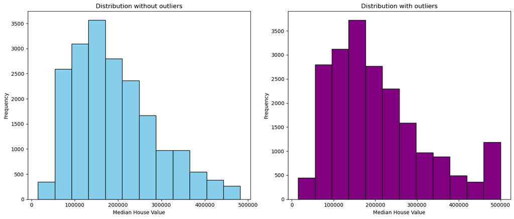

```python
import matplotlib.pyplot as plt

clean_mdn_house = [x for x in mdn_house if x is not None]
cleaned_data_without_outliers = [x for x in clean_mdn_house if x not in outliers]

# Create a bigger figure
plt.figure(figsize=(14,6))  # width=14, height=6

# Histogram without outliers
plt.subplot(1,2,1)
plt.hist(cleaned_data_without_outliers, bins=12, edgecolor="black", color="skyblue")
plt.title("Distribution without outliers")
plt.xlabel("Median House Value")
plt.ylabel("Frequency")

# Histogram with outliers
plt.subplot(1,2,2)
plt.hist(clean_mdn_house, bins=12, edgecolor="black", color="purple")
plt.title("Distribution with outliers")
plt.xlabel("Median House Value")
plt.ylabel("Frequency")

# Adjust spacing automatically so labels and titles don't overlap
plt.tight_layout()

plt.show()
```

```python
print(len(clean_mdn_house))
print(len(cleaned_data_without_outliers))
```

```
20640
19569
```

**8. Print a short summary describing distribution shape and outliers • Mention which visualization helped most and why ?**

**The distribution of median house values is right-skewed (positively skewed), meaning most values are concentrated at the lower end with a long tail toward higher prices.The boxplot helped most in identifying outliers and I find 1071 outliers are present , as it clearly shows values outside the whiskers.The histogram and KDE show the overall distribution shape, but the boxplot is the most effective for spotting extreme values. If I wanted to understand the data distribution I would choose histogram or KDE but I will prefer KDE and if I wanted to detect outliers I would choose boxplot.**

### ADDITIONAL QUESTIONS

**1. Plot a histogram for a numerical column and explain how the choice of bin size affects the shape of the distribution.**

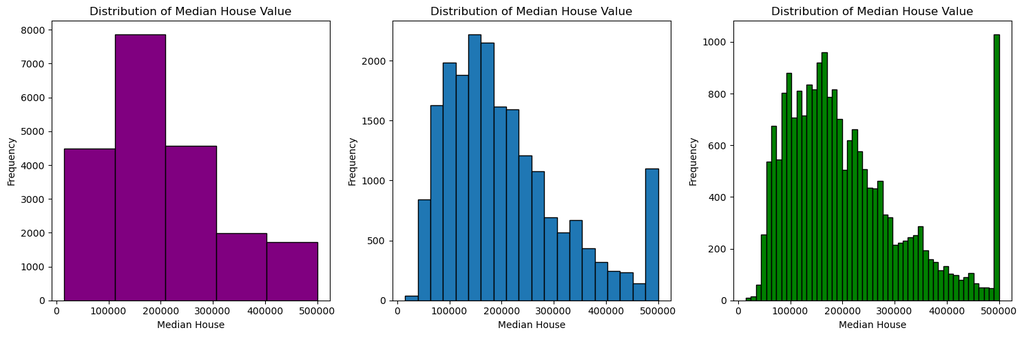

```python
import matplotlib.pyplot as plt
clean_mdn_house =[x for x in mdn_house if x is not None]
plt.figure(figsize=(15,5))

plt.subplot(1,3,1)
plt.hist(clean_mdn_house,edgecolor="black", bins=5,color="purple")
plt.title("Distribution of Median House Value")
plt.xlabel("Median House")
plt.ylabel("Frequency")

plt.subplot(1,3,2)
plt.hist(clean_mdn_house,edgecolor="black", bins=20)
plt.title("Distribution of Median House Value")
plt.xlabel("Median House")
plt.ylabel("Frequency")

plt.subplot(1,3,3)
plt.hist(clean_mdn_house,edgecolor="black", bins=50,color="green")
plt.title("Distribution of Median House Value")
plt.xlabel("Median House")
plt.ylabel("Frequency")

plt.tight_layout()
plt.show()
```

**The choice of bin size in a histogram affects how the distribution appears: too few bins oversmooth the data and hide details, while too many bins make the histogram noisy. An appropriate number of bins reveals the true shape, skewness, and spread of the data**

- 5 bins → Very smooth, details hidden
- 20 bins → Good balance, shape visible
- 50 bins → Very jagged, noisy

**2. Write code to plot histograms for two different columns on separate figures and compare their distributions.**

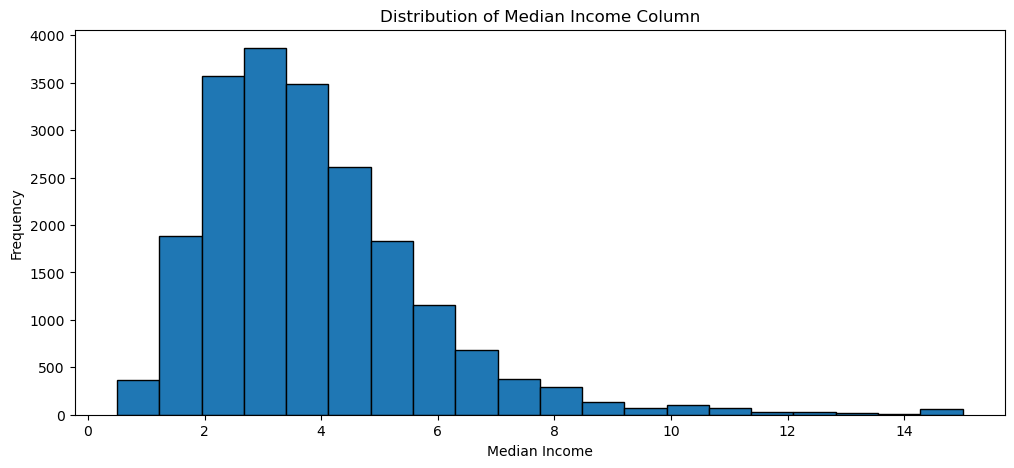

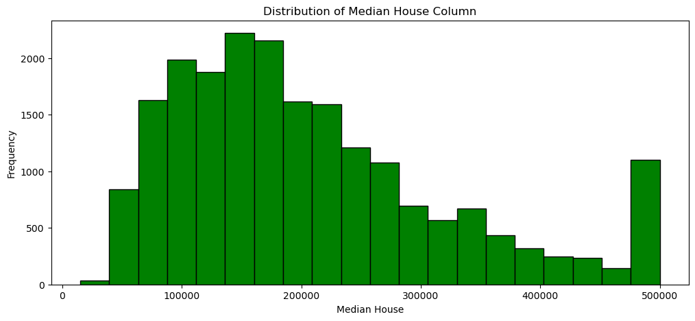

```python
mdn_income = data["median_income"]    # since i already have loaded the csv file in Q1.
clean_mdn_income = [x for x in mdn_income if x is not None]
clean_mdn_house =[x for x in mdn_house if x is not None]
# for income column
plt.figure(figsize=(12,5))
plt.hist(clean_mdn_income, edgecolor="black" , bins =20)
plt.title("Distribution of Median Income Column")
plt.xlabel("Median Income")
plt.ylabel("Frequency")
plt.show()

# for median house column
plt.figure(figsize=(12,5))
plt.hist(clean_mdn_house, edgecolor="black" , bins =20,color="green")
plt.title("Distribution of Median House Column")
plt.xlabel("Median House")
plt.ylabel("Frequency")
plt.show()
```

The **median income distribution** is right-skewed, with most values concentrated in the lower to middle range and fewer observations at higher income levels. This indicates that the majority of households earn moderate incomes, while high-income values are relatively rare.

The **median house value distribution** is also right-skewed but shows a much wider spread. Most house values lie in the mid-price range, with a long tail toward higher prices and a clear cap near the maximum value, indicating greater variability in housing prices compared to income.

**3. Plot a density (KDE) curve and explain how it differs from a histogram.**

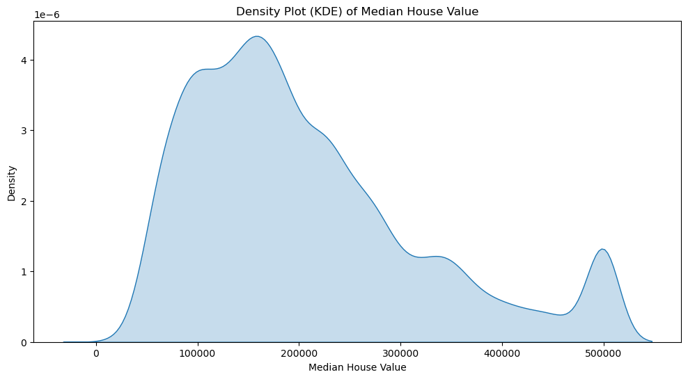

```python
import seaborn as sns
import matplotlib.pyplot as plt

# Remove None values
clean_mdn_house = [x for x in mdn_house if x is not None]

plt.figure(figsize=(12, 6))
sns.kdeplot(clean_mdn_house, fill=True)

plt.title("Density Plot (KDE) of Median House Value")
plt.xlabel("Median House Value")
plt.ylabel("Density")

plt.show()
```

| Feature | Histogram | Density Plot (KDE) |
| --- | --- | --- |
| Representation | Uses **bars** | Uses a **smooth continuous curve** |
| Y-axis meaning | **Frequency** (count of values in bins) | **Density** (probability distribution) |
| Depends on bins | Yes (bin size strongly affects shape) | No bins used |
| Smoothness | Discrete and block-like | Smooth and continuous |
| Shape clarity | Rough view of distribution | Clear view of distribution shape |
| Skewness detection | Possible but less clear | Very clear (left/right skewness) |
| Multiple peaks (modes) | Harder to identify | Easier to identify |
| Best used when | You want **counts per range** | You want **overall distribution pattern** |

**4. Plot both histogram and density plot for the same data and explain what additional insight the density plot gives.**

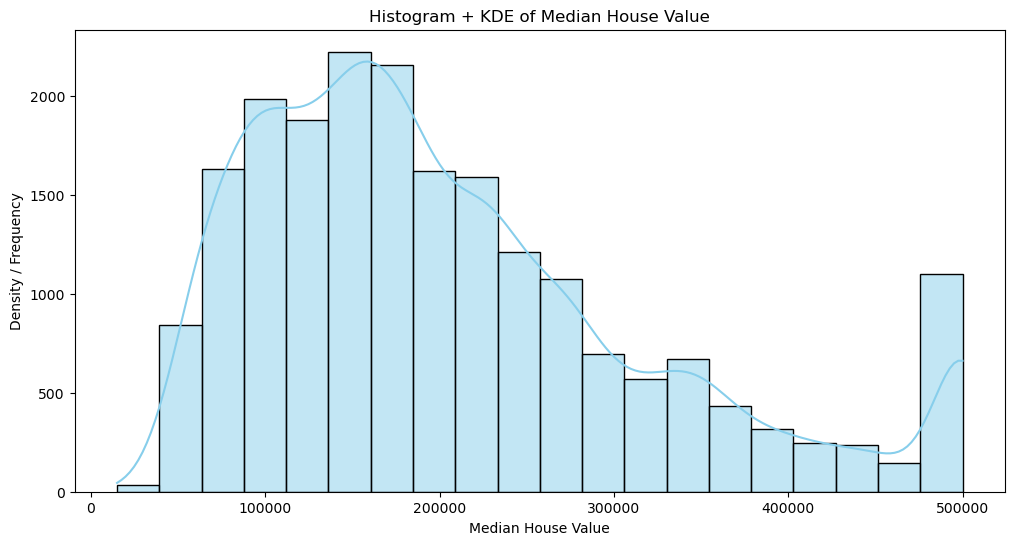

```python
import matplotlib.pyplot as plt
import seaborn as sns

# Clean data
clean_mdn_house = [x for x in mdn_house if x is not None]

plt.figure(figsize=(12, 6))

# Plot histogram with density normalized
sns.histplot(clean_mdn_house,bins=20, color='skyblue', edgecolor='black', kde=True)

plt.title("Histogram + KDE of Median House Value")
plt.xlabel("Median House Value")
plt.ylabel("Density / Frequency")
plt.show()
```

**When both a histogram and a density plot (KDE) are plotted for the same data, the histogram shows the actual frequency of observations within fixed value ranges (bins), helping us understand how data is distributed across intervals. However, the appearance of a histogram can change significantly depending on the chosen bin size. The density plot adds deeper insight by providing a smooth, continuous representation of the underlying distribution, making it easier to clearly observe the overall shape, skewness, and areas where values are most concentrated. Unlike the histogram, the KDE is not affected by bin selection, so it reveals the true pattern of the data more reliably. Together, these plots give a complete understanding of both the frequency and the distribution behavior of the data.**

**5. Create a boxplot for a numerical column and identify the lower and upper quartiles.**

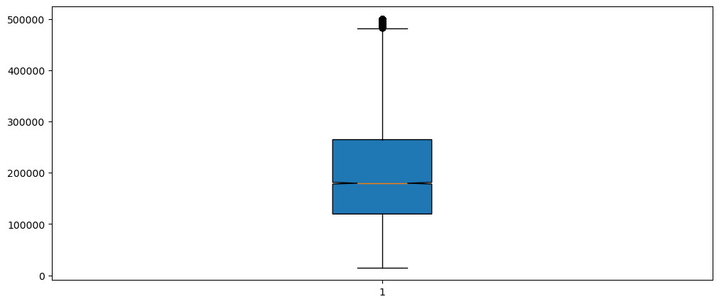

```
The value of Q1=119600.0 and Q3=264775.0
```

```python
import matplotlib.pyplot as plt
clean_mdn_house = [x for x in mdn_house if x is not None]
plt.figure(figsize=(12,5))
plt.boxplot(clean_mdn_house,
           vert = True,
            patch_artist=True,
           notch=True,)
plt.show()

def get_quartile(data, q):

    if not data:
        return None
    if q not in (1, 2, 3):
        raise ValueError("q must be 1, 2, or 3")

    data = sorted(data)
    n = len(data)
    pos = q * (n+1) / 4

    if pos<=1:
        return data[0]
    if pos>=n:
        return data[-1]

    lower = int(pos) - 1
    upper = lower + 1
    fraction = pos - int(pos)
    return data[lower] + fraction * (data[upper] - data[lower])

Q1 =get_quartile(clean_mdn_house,1)
Q3 =get_quartile(clean_mdn_house,3)
print(f"The value of Q1={Q1} and Q3={Q3}")
```

**6. From the boxplot, extract the IQR value programmatically and print it**

```python
def get_quartile(data, q):

    if not data:
        return None
    if q not in (1, 2, 3):
        raise ValueError("q must be 1, 2, or 3")

    data = sorted(data)
    n = len(data)
    pos = q * (n+1) / 4

    if pos<=1:
        return data[0]
    if pos>=n:
        return data[-1]

    lower = int(pos) - 1
    upper = lower + 1
    fraction = pos - int(pos)
    return data[lower] + fraction * (data[upper] - data[lower])

Q1 =get_quartile(clean_mdn_house,1)
Q3 =get_quartile(clean_mdn_house,3)
IQR = Q3 -Q1
print("The IQR value = ",IQR)
```

```
The IQR value =  145175.0
```

**7. Identify outliers using the boxplot rule (1.5 × IQR) and print their count.**

```python
def get_quartile(data, q):

    if not data:
        return None
    if q not in (1, 2, 3):
        raise ValueError("q must be 1, 2, or 3")

    data = sorted(data)
    n = len(data)
    pos = q * (n+1) / 4

    if pos<=1:
        return data[0]
    if pos>=n:
        return data[-1]

    lower = int(pos) - 1
    upper = lower + 1
    fraction = pos - int(pos)
    return data[lower] + fraction * (data[upper] - data[lower])

Q1 =get_quartile(clean_mdn_house,1)
Q3 =get_quartile(clean_mdn_house,3)
IQR = Q3 -Q1
lower_half = Q1 - 1.5 * IQR
upper_half = Q3 + 1.5 * IQR
outliers =[]
for num in clean_mdn_house:
    if num <lower_half or num > upper_half:
        outliers.append(num)
print("The length of outliers is" ,len(outliers))
```

```
The length of outliers is 1071
```

**8. Plot a boxplot before and after removing outliers and compare the visual difference.**

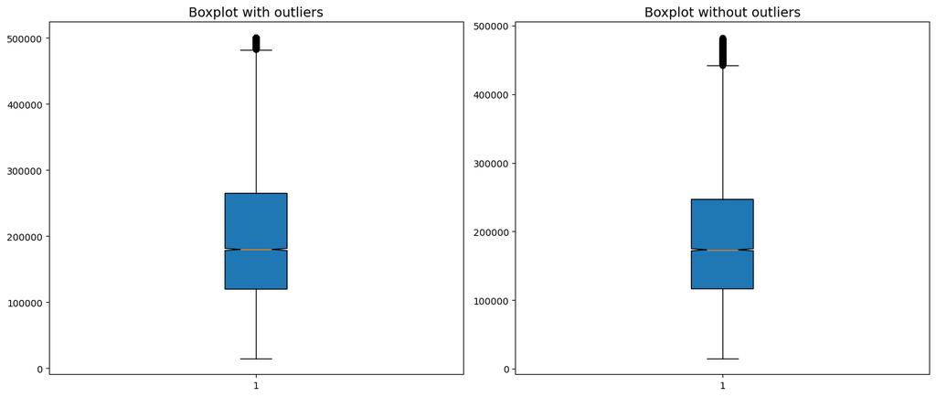

```python
import matplotlib.pyplot  as plt
clean_mdn_house = [x for x in mdn_house if x is not None]
clean_mdn_house_no_outliers= [x for x in clean_mdn_house if x not in outliers]

plt.figure(figsize=(14,6))
plt.subplot(1,2,1)
plt.boxplot(clean_mdn_house,vert=True, patch_artist=True, notch=True)
plt.title("Boxplot with outliers",fontsize=14)

plt.subplot(1,2,2)
plt.boxplot(clean_mdn_house_no_outliers,vert=True, patch_artist=True, notch=True)
plt.title("Boxplot without outliers",fontsize=14)

plt.tight_layout()
plt.show()
```

**9. Write a function that takes a column name and automatically plots its histogram and boxplot.**

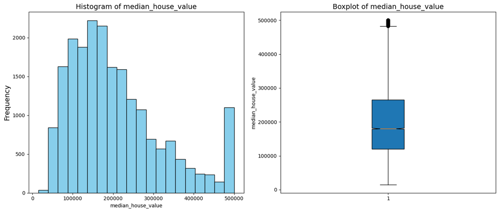

```python
import matplotlib.pyplot as plt

def plot_histogram_boxplot(data_dict, column_name, bins=20):

    # Check if column exists
    if column_name not in data_dict:
        print(f"Column '{column_name}' not found in data.")
        return

    # Clean the data (remove None values)
    column_data = [x for x in data_dict[column_name] if x is not None]

    if not column_data:
        print(f"No valid data in column '{column_name}'")
        return

    # Create figure with 2 subplots
    plt.figure(figsize=(14,6))

    # Histogram
    plt.subplot(1,2,1)
    plt.hist(column_data, bins=bins, edgecolor='black', color='skyblue')
    plt.title(f"Histogram of {column_name}",fontsize=14)
    plt.xlabel(column_name)
    plt.ylabel("Frequency",fontsize=14)

    # Boxplot
    plt.subplot(1,2,2)
    plt.boxplot(column_data, vert=True, patch_artist=True, notch=True,
               )
    plt.title(f"Boxplot of {column_name}",fontsize=14)
    plt.ylabel(column_name)

    plt.tight_layout()
    plt.show()
res=plot_histogram_boxplot(data,"median_house_value",20)
```

**10. Compare two boxplots of different columns and explain which one has higher variability.**

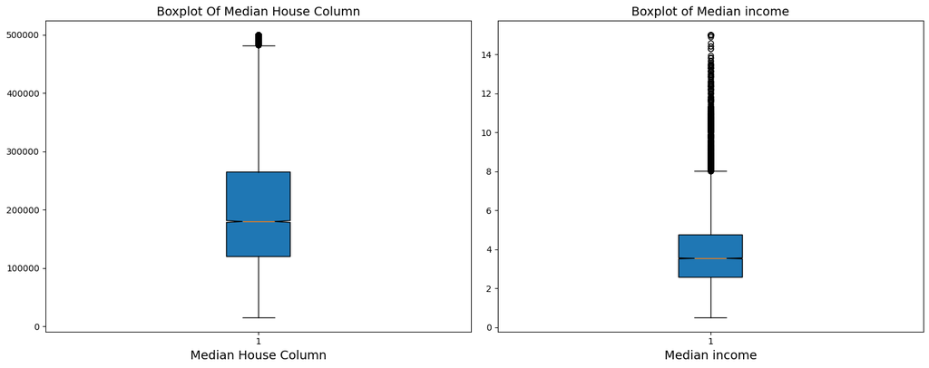

```python
# see i have imported already 2 columns in Q1 so i am not using function this time
import matplotlib.pyplot  as plt
clean_mdn_house = [x for x in mdn_house if x is not None]
clean_mdn_income =[x for x in mdn_income if x is not None]

plt.figure(figsize=(15,6))
plt.subplot(1,2,1)
plt.boxplot(clean_mdn_house,vert=True, patch_artist=True, notch=True)
plt.title("Boxplot Of Median House Column",fontsize=14)
plt.xlabel("Median House Column",fontsize=14)

plt.subplot(1,2,2)
plt.boxplot(clean_mdn_income,vert=True, patch_artist=True, notch=True)
plt.title("Boxplot of Median income",fontsize=14)
plt.xlabel("Median income",fontsize=14)

plt.tight_layout()
plt.show()
```

**11. Use subplots to display histogram and boxplot for the same column side-by-side.**

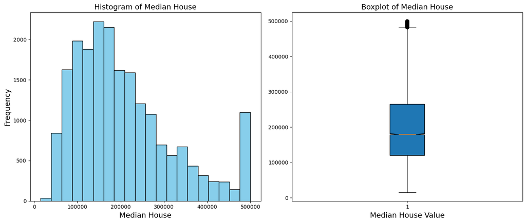

```python
import matplotlib.pyplot as plt
clean_mdn_house =[ x for x in mdn_house if x is not None]

plt.figure(figsize=(14,6))

# Histogram
plt.subplot(1,2,1)
plt.hist(clean_mdn_house, bins=20, edgecolor='black', color='skyblue')
plt.title(f"Histogram of Median House",fontsize=14)
plt.xlabel("Median House",fontsize =14)
plt.ylabel("Frequency",fontsize=14)

plt.subplot(1,2,2)
plt.boxplot(clean_mdn_house, vert=True, patch_artist=True, notch=True,)
plt.title(f"Boxplot of Median House",fontsize=14)
plt.xlabel("Median House Value",fontsize=14)
plt.tight_layout()
plt.show()
```

**12. Plot density plots for two different columns on the same figure and analyze overlap.**

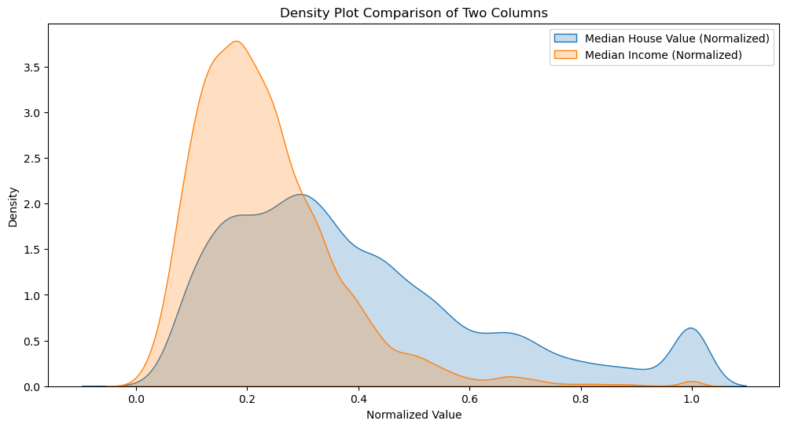

```python
import seaborn as sns
import matplotlib.pyplot as plt

# Clean data
clean_mdn_house = [x for x in mdn_house if x is not None]
clean_mdn_income = [x for x in mdn_income if x is not None]

# Min-max normalization (pure Python)
def normalize(data):
    min_val = min(data)
    max_val = max(data)
    return [(x - min_val) / (max_val - min_val) for x in data]

house_norm = normalize(clean_mdn_house)
income_norm = normalize(clean_mdn_income)

# Plot both density curves on same figure
plt.figure(figsize=(12,6))
sns.kdeplot(house_norm, fill=True, label="Median House Value (Normalized)")
sns.kdeplot(income_norm, fill=True, label="Median Income (Normalized)")

plt.title("Density Plot Comparison of Two Columns")
plt.xlabel("Normalized Value")
plt.ylabel("Density")
plt.legend()
plt.show()
```

**The density plot shows the distribution of Median House Value and Median Income on the same normalized scale. Median Income has a sharp, narrow peak at lower normalized values, indicating that most income values are concentrated within a small range and have lower variability. In contrast, Median House Value displays a wider and more spread-out curve with a long right tail, showing higher variability. The overlapping area of the two curves indicates ranges where both variables share similar relative distributions, suggesting a potential relationship between income levels and house values. Normalization was applied to bring both columns to a common scale (0–1), enabling a fair comparison of their distribution shapes without distortion caused by differing units and magnitudes.**

**13. Explain how skewness is visible in histograms and boxplots.**

In a **histogram**, skewness is identified by the length of the tail. If the bars extend longer toward the right side (higher values), the distribution is positively skewed (right-skewed), meaning most values are concentrated on the lower side with a few large values pulling the tail right. If the tail extends toward the left side (lower values), the distribution is negatively skewed (left-skewed). A symmetric distribution shows roughly equal spread on both sides of the center.

In a **boxplot**, skewness is seen through the position of the median, the length of the whiskers, and the location of outliers. For positive skewness, the median is closer to Q1, the upper whisker is longer, and outliers often appear on the higher-value side. For negative skewness, the median is closer to Q3, the lower whisker is longer, and outliers appear on the lower side. If the median is centered and whiskers are similar in length, the distribution is approximately symmetric.

**14. Modify your histogram code to normalize the frequency (probability density)**

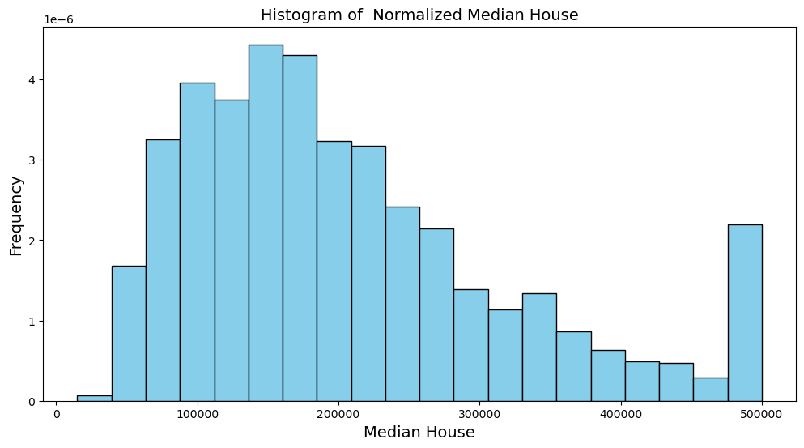

```python
import matplotlib.pyplot as plt

# Clean data
clean_mdn_house = [x for x in mdn_house if x is not None]


# Plot histogram
plt.figure(figsize=(12,6))
plt.hist(clean_mdn_house, bins=20, edgecolor='black', color='skyblue',density=True)  # density = True normalizes the frequency
# if we are said to normalize the data then min-max can be used okay  just my guess
plt.title(f"Histogram of  Normalized Median House",fontsize=14)
plt.xlabel("Median House",fontsize =14)
plt.ylabel("Frequency",fontsize=14)
plt.show()
```

**15. Write code to detect whether a distribution is approximately normal using visualization only**

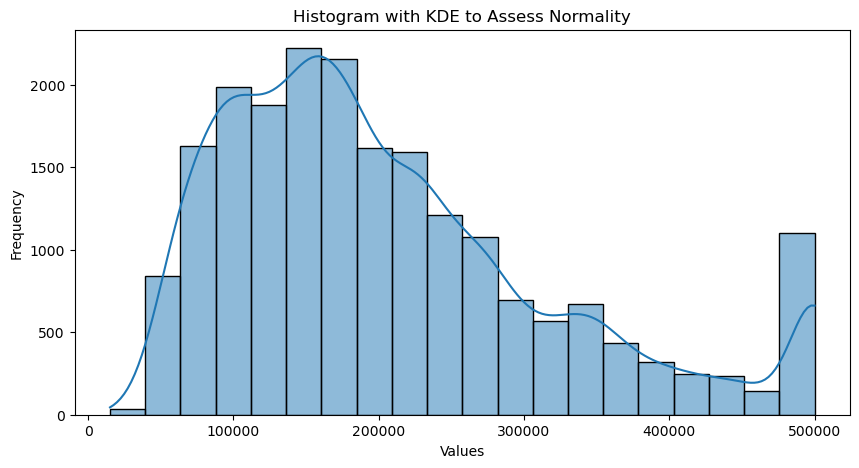

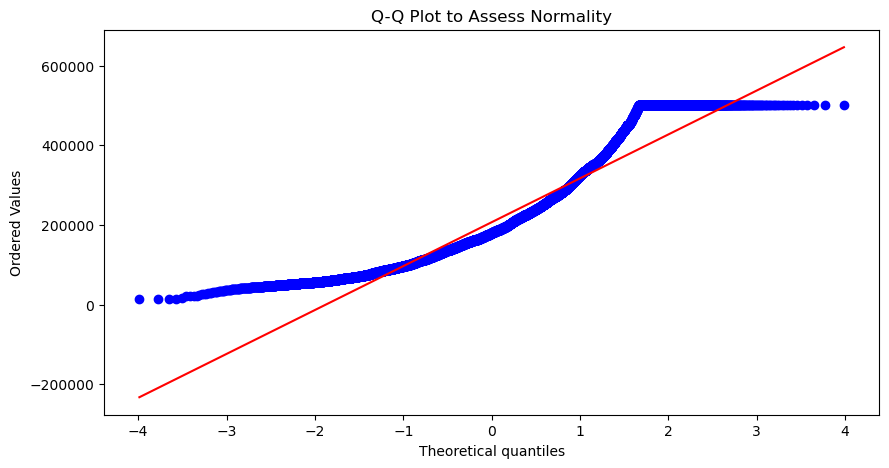

```python
import matplotlib.pyplot as plt
import seaborn as sns
import scipy.stats as stats

# Clean the data
clean_mdn_house = [x for x in mdn_house if x is not None]

# 1. Histogram with KDE
plt.figure(figsize=(10, 5))
sns.histplot(clean_mdn_house, bins=20, kde=True)
plt.title("Histogram with KDE to Assess Normality")
plt.xlabel("Values")
plt.ylabel("Frequency")
plt.show()

# 2. Q-Q Plot
plt.figure(figsize=(10, 5))
stats.probplot(clean_mdn_house, dist="norm", plot=plt)
plt.title("Q-Q Plot to Assess Normality")
plt.show()
```

**16. After removing outliers, recompute mean and median and explain the change.**

```python
def mean(data):
    return sum(data) / len(data)

def median(data):
    data = sorted(data)
    n = len(data)
    mid = n //2
    if n%2 == 0:
        return (data[mid-1]+ data[mid])/ 2
    else:
        return data[mid]
def get_quartile(data,q):
    if not data:
        return None
    if q not in (1,2,3):
        print("Quartiles can only be 1,2,3")
        return
    data = sorted(data)
    n = len(data)
    pos = q *(n+1) / 4

    if pos<=1:
        return data[0]
    if pos>=n:
        return data[-1]
    lower = int(pos) - 1
    upper = lower+1
    fraction = pos - int(pos)
    return data[lower] + fraction * (data[upper] - data[lower])

clean_mdn_house = [x for x in mdn_house if x is not None]
q1 = get_quartile(clean_mdn_house,1)
q3 = get_quartile(clean_mdn_house,3)

iqr =  q3 -q1
lower_half = q1 - 1.5*iqr
upper_half = q3 + 1.5 *iqr

outliers= [ num for num in clean_mdn_house if num<lower_half or num >upper_half]
print("The length of clean median house", len(clean_mdn_house))
print("The length of outliers is ", len(outliers))

no_outlier_cln_data = [x for x in clean_mdn_house if x not in outliers]
print("The length after removing outliers is ", len(no_outlier_cln_data))

mean1 = mean(clean_mdn_house)
mean2 = mean(no_outlier_cln_data)
median1=median(clean_mdn_house)
median2 = median(no_outlier_cln_data)

print(f"The value of mean before removing outliers={mean1} and after removing outliers is {mean2}")
print(f"The value of median before removing outliers={median1} and after removing outliers is {median2}")
print("\nwe came to conclusion that mean is moslty affected by outliers as compared to median because median is \nbased on position and is also robust to outliers. as we can also clearly see in the results.")
```

```
The length of clean median house 20640
The length of outliers is  1071
The length after removing outliers is  19569
The value of mean before removing outliers=206855.81690891474 and after removing outliers is 190852.30190607594
The value of median before removing outliers=179700.0 and after removing outliers is 173200.0

we came to conclusion that mean is moslty affected by outliers as compared to median because median is
based on position and is also robust to outliers. as we can also clearly see in the results.
```

**17. Plot histograms for raw data and cleaned data and describe differences.**

**See after clearly visualizing the data in california housing dataset column I came to conclusion that there is no any null value present in the data (0) so i check for the duplicated column and duplicated column too doesn't exists so the histogram would be the same So I have randomly taken one raw_data and i cleaned it and plot the histogram to understand differences.**

```
100
82
Matplotlib cannot handle null values like None so it throws error while plotting it so we must always clean the data before plotting.
So i have commented out the part of plotting histogram of raw_data.
```

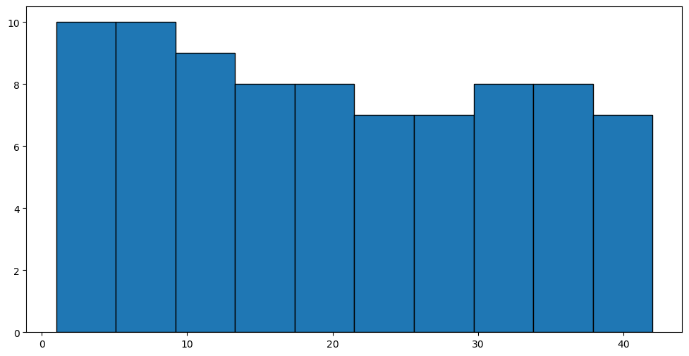

```python
raw_data = [
12, 7, 34, None, 23, 8, 15, 42, 9, 31,
None, 18, 27, 5, 40, 21, None, 14, 33, 2,
6, 38, 19, None, 11, 29, 4, 24, 16, None,
36, 3, 20, 30, 10, None, 17, 25, 1, 39,
8, None, 32, 13, 22, 37, None, 26, 35, 7,
2, 41, None, 12, 28, 9, 14, None, 19, 30,
21, None, 6, 34, 11, 38, None, 5, 27, 16,
33, None, 20, 3, 31, 15, None, 24, 18, 36,
1, None, 22, 39, 4, 29, None, 10, 23, 37,
12, None, 7, 32, 26, None, 13, 35, 17, 8
]
clean_data = [x for x in raw_data if x is not None]
print(len(raw_data))
print(len(clean_data))
# plt.figure(figsize=(12,6))
# plt.hist(raw_data)
# plt.show()
print("Matplotlib cannot handle null values like None so it throws error while plotting it so we must always clean the data before plotting."
"\nSo i have commented out the part of plotting histogram of raw_data.")
plt.figure(figsize=(12,6))
plt.hist(clean_data,edgecolor="black")
plt.show()
```

**18. Explain why boxplots are better than histograms for detecting outliers.**

**Boxplots are better than histograms for detecting outliers because they visually highlight extreme values beyond the whiskers, making outliers easy to spot. They also summarize the data using quartiles and median, providing a clear picture of spread and symmetry, whereas histograms show the overall distribution but don’t explicitly mark individual outliers, so extreme values can be hidden in the bins.**

**19. Write a reusable visualization function that accepts: • dataset • column name • plot type (histogram / density / boxplot)**

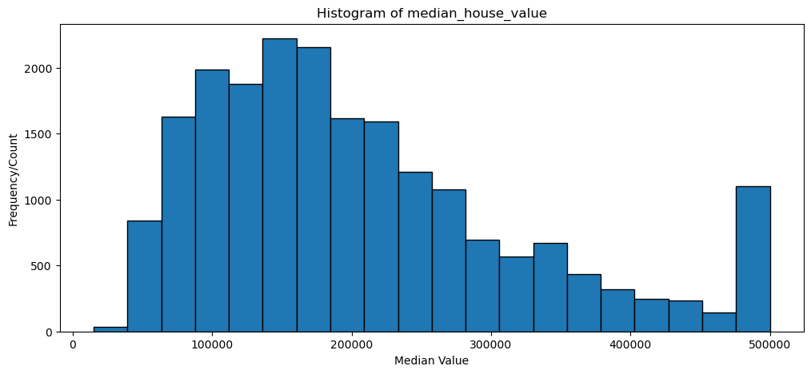

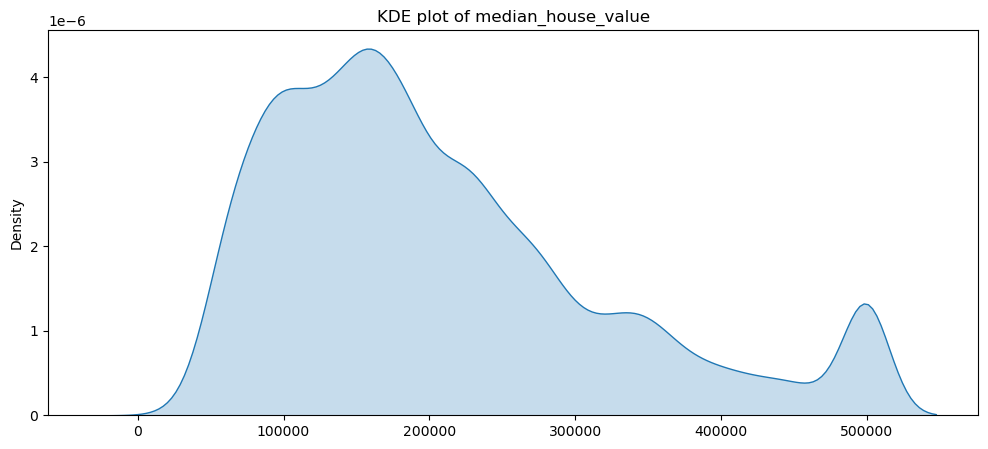

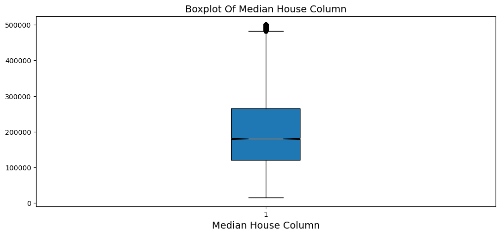

```python
import matplotlib.pyplot as plt
import seaborn as sns

def visualization(dataset,column_name,plot_type="histogram"):

    # Check if column exists
    if column_name not in dataset:
        print(f"Column '{column_name}' not found in data.")
        return

    # Clean the data (remove None values)
    column_data = [x for x in dataset[column_name] if x is not None]

    if not column_data:
        print(f"No valid data in column '{column_name}'")
        return
    plt.figure(figsize=(12,5))
    if plot_type=="histogram":
        plt.hist(column_data,bins=20,edgecolor="black")
        plt.title(f"Histogram of {column_name}")
        plt.xlabel("Median Value")
        plt.ylabel("Frequency/Count")
        plt.show()
    elif plot_type=="density":
        sns.kdeplot(column_data,fill=True)
        plt.title(f"KDE plot of {column_name}")
        plt.show()
    elif plot_type=="boxplot":
        plt.boxplot(column_data ,vert=True, patch_artist=True, notch=True)
        plt.title("Boxplot Of Median House Column",fontsize=14)
        plt.xlabel("Median House Column",fontsize=14)
    else:
        raise ValueError("plot_type can only be histogram, density, boxplot.")

hist=visualization(data,"median_house_value", "histogram")
kde=visualization(data,"median_house_value", "density")
bxplot=visualization(data,"median_house_value", "boxplot")
```

**20. Automatically detect skewness direction using mean and median and validate it visually using plots.**

```
Positive/Right skewed
Lets prove this same with visualization boxplot
```

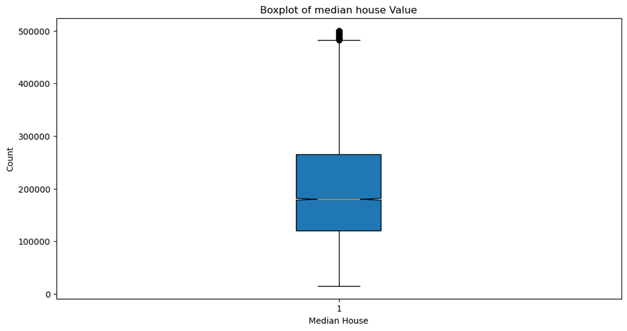

```python
import matplotlib.pyplot as plt

def mean(data):
    if not data:
        return None
    return sum(data) / len(data)

def median(data):
    if not data:
        return None

    data = sorted(data)
    n = len(data)
    mid = n //2
    if n%2 == 0:
        return (data[mid-1]+ data[mid])/ 2
    else:
        return data[mid]

def skewness(data):
    mean1= mean(data)
    mdn= median(data)

    if mean1 == mdn:
        print("Symmetric skewness")
    elif mean1>mdn:
        print("Positive/Right skewed")
    else:
        print("Negative/Left skewed.")
clean_mdn_house= [ x for x in mdn_house if x is not None]
xyz=skewness(clean_mdn_house)
print("Lets prove this same with visualization boxplot")

plt.figure(figsize=(12,6))
plt.boxplot(clean_mdn_house,vert=True, patch_artist=True,notch=True)
plt.title("Boxplot of median house Value")
plt.xlabel("Median House")
plt.ylabel("Count")
plt.show()
```

**21. Write code to compare distributions of the same feature across two datasets.**

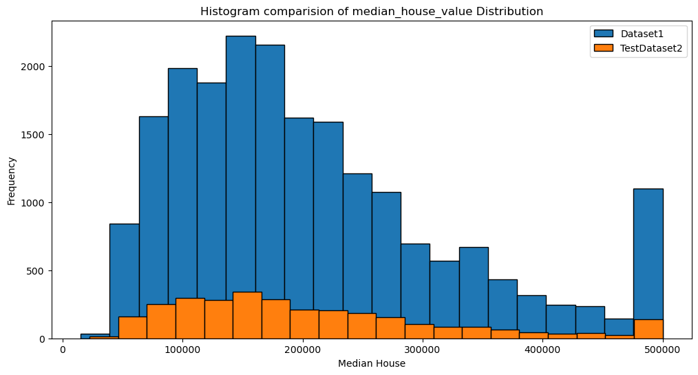

```python
import matplotlib.pyplot as plt
def compare_distribution(dataset1,dataset2, column_name):
    if  column_name not in dataset1 or  column_name not in dataset2:
        print(f"No {column_name} column exist in the dataset")
        return
    column_data1 = [x for x in dataset1[column_name] if x is not None]
    column_data2 = [x for x in dataset2[column_name] if x is not None]

    if not column_data1 or not column_data2:
        print("No any valid data found in this column")
        return

    plt.figure(figsize=(12,6))
    plt.hist(column_data1,edgecolor="black",bins=20,label="Dataset1")
    plt.hist(column_data2,edgecolor="black",bins=20,label="TestDataset2")
    plt.title(f"Histogram comparision of {column_name} Distribution")
    plt.xlabel("Median House")
    plt.ylabel("Frequency")
    plt.legend()
    plt.show()

df1= compare_distribution(data,testdata, "median_house_value")
```

**22. Plot boxplots for multiple numerical columns in one figure and analyze which feature is most variable.**

**Boxplot with Normalization**

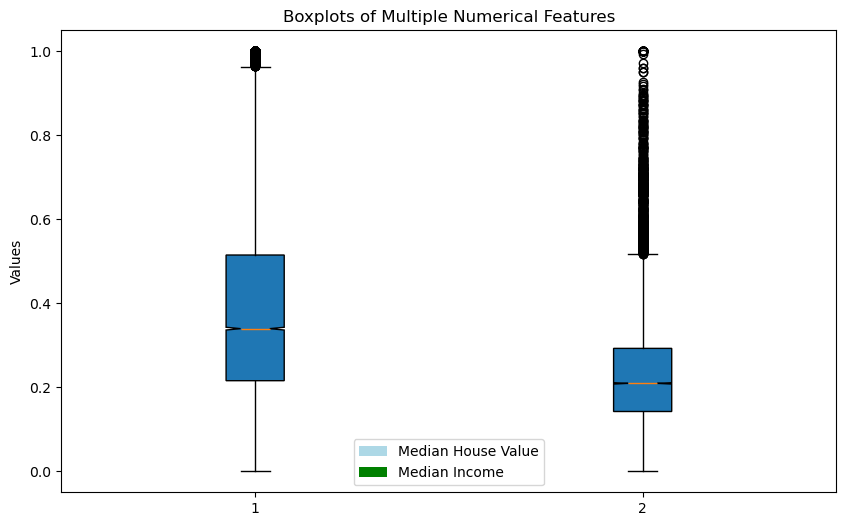

```python
import matplotlib.pyplot as plt
from matplotlib.patches import Patch

# Clean data
clean_mdn_house = [x for x in mdn_house if x is not None]
clean_mdn_income = [x for x in mdn_income if x is not None]

plt.figure(figsize=(10, 6))

def normalize(data):
    min_val = min(data)
    max_val=max(data)
    return [(x-min_val)/ (max_val - min_val) for x in data]

mdn_house_normalize= normalize(clean_mdn_house)
mdn_income_normalize= normalize(clean_mdn_income)

box = plt.boxplot(
    [mdn_house_normalize, mdn_income_normalize],
    vert=True,
    patch_artist=True,
    notch=True
)

# Manually create legend
legend_elements = [
    Patch(facecolor='lightblue', label='Median House Value'),
    Patch(facecolor='green', label='Median Income')
]

plt.legend(handles=legend_elements)

plt.title("Boxplots of Multiple Numerical Features")
plt.ylabel("Values")
plt.show()
```

**Boxplot without normalization**

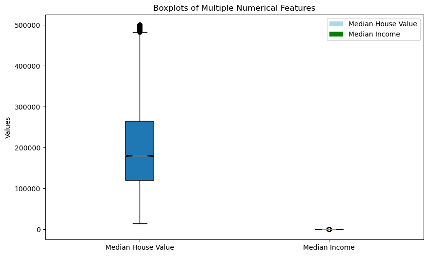

```python
import matplotlib.pyplot as plt

# Clean data (remove None values)
clean_mdn_house = [x for x in mdn_house if x is not None]
clean_mdn_income = [x for x in mdn_income if x is not None]

plt.figure(figsize=(10,6))

plt.boxplot(
    [clean_mdn_house, clean_mdn_income],
    labels=["Median House Value", "Median Income"],
    vert=True,
    notch=True,
    patch_artist=True
)

legend_elements = [
    Patch(facecolor='lightblue', label='Median House Value'),
    Patch(facecolor='green', label='Median Income')
]

plt.legend(handles=legend_elements)

plt.title("Boxplots of Multiple Numerical Features")
plt.ylabel("Values")
plt.show()
```

From the boxplots, Median House Value shows significantly higher variability than Median Income. This is evident from its much larger interquartile range (IQR), longer whiskers, and the presence of several outliers. In contrast, Median Income has a very small IQR and short whiskers, indicating low variability. Therefore, Median House Value is the most variable feature.

**23. Use quantiles (10%, 25%, 50%, 75%, 90%) and explain how they relate to boxplots.**

```python
def get_quantiles(data,p):
    if not data:
        return None

    data = sorted(data)
    n = len(data)
    pos = (p/100) * (n-1)

    lower = int(pos)
    upper = lower+1

    if upper>=n:
        return data[lower]

    fraction = pos - int(pos)
    return data[lower] + fraction * (data[upper] - data[lower])

clean_mdn_house = [x for x in mdn_house if x is not None]
ten_per= get_quantiles(clean_mdn_house,10)
tnyfive_per= get_quantiles(clean_mdn_house,25)
fifty_per= get_quantiles(clean_mdn_house,50)
svntyfive_per= get_quantiles(clean_mdn_house,75)
ninety_per= get_quantiles(clean_mdn_house,90)
print(f"The value in 10% quantiles is {ten_per}")
print(f"The value in 25% quantiles is {tnyfive_per}")
print(f"The value in 50% quantiles is {fifty_per}")
print(f"The value in 75% quantiles is {svntyfive_per}")
print(f"The value in 90% quantiles is {ninety_per}")
```

```
The value in 10% quantiles is 82300.0
The value in 25% quantiles is 119600.0
The value in 50% quantiles is 179700.0
The value in 75% quantiles is 264725.0
The value in 90% quantiles is 376600.0
```

**Quantiles divide a dataset into equal parts based on percentages. The 10%, 25%, 50%, 75%, and 90% quantiles represent the values below which 10%, 25%, 50%, 75%, and 90% of the data lie, respectively. In a boxplot, the 25% quantile (Q1) and 75% quantile (Q3) form the lower and upper edges of the box, while the 50% quantile (median) is shown as a line inside the box. The interquartile range (IQR = Q3 − Q1) measures data spread. Whiskers extend to the smallest and largest values within 1.5 × IQR, and values beyond this range are plotted as outliers. The 10% and 90% quantiles help understand the distribution tails but are not used directly in boxplot construction or outlier detection**

**24. Write a function that flags extreme outliers (beyond 3 × IQR) and visualize them.**

```
Total number of valid data points: 20640
Number of extreme outliers detected: 140
```

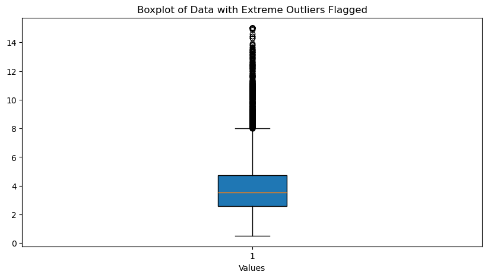

```python
import matplotlib.pyplot as plt

def get_quartile(data, q):
    """Returns the q-th quartile of a numeric dataset."""
    if not data:
        return None
    if q not in (1, 2, 3):
        print("Error: Quartiles can only be 1, 2, or 3.")
        return None

    data = sorted(data)
    n = len(data)
    pos = q * (n + 1) / 4

    if pos <= 1:
        return data[0]
    elif pos >= n:
        return data[-1]

    lower = int(pos) - 1
    upper = lower + 1
    fraction = pos - int(pos)
    return data[lower] + fraction * (data[upper] - data[lower])


def flag_extreme_outliers(data):
    """Flags extreme outliers (beyond 3 × IQR) and returns a dictionary with flags."""
    clean_data = [x for x in data if x is not None]

    q1 = get_quartile(clean_data, 1)
    q3 = get_quartile(clean_data, 3)
    iqr = q3 - q1

    lower_bound = q1 - 3 * iqr
    upper_bound = q3 + 3 * iqr

    flags = ["Extreme Outlier" if (x < lower_bound or x > upper_bound) else "Normal" for x in clean_data]

    return clean_data, flags, lower_bound, upper_bound


# Apply the function
clean_data, flags, lower, upper = flag_extreme_outliers(mdn_income)

# Print summary
print("Total number of valid data points:", len(clean_data))
print("Number of extreme outliers detected:", flags.count("Extreme Outlier"))

# Visualize using a boxplot
plt.figure(figsize=(10, 5))
plt.boxplot(clean_data, vert=True, patch_artist=True,)
plt.title("Boxplot of Data with Extreme Outliers Flagged")
plt.xlabel("Values")
plt.show()
```

**25. Compare IQR-based outliers vs Z-score-based outliers and visualize both.**

```
Number of IQR outliers: 679
Number of Z-score outliers: 345
```

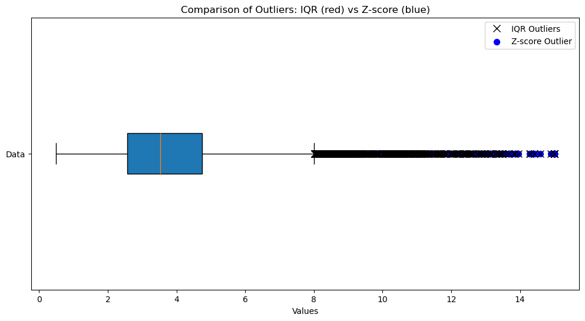

```python
import matplotlib.pyplot as plt

# Function to calculate mean
def mean(data):
    if not data:
        return None
    return sum(data) / len(data)

# Function to calculate standard deviation
def std_dev(data):
    m = mean(data)
    var = sum((x - m) ** 2 for x in data) / len(data)
    return var ** 0.5

# Function to get quartiles
def get_quartile(data, q):
    """Returns the q-th quartile of a numeric dataset."""
    if not data:
        return None
    if q not in (1, 2, 3):
        print("Error: Quartiles can only be 1, 2, or 3.")
        return None

    data = sorted(data)
    n = len(data)
    pos = q * (n + 1) / 4

    if pos <= 1:
        return data[0]
    elif pos >= n:
        return data[-1]

    lower = int(pos) - 1
    upper = lower + 1
    fraction = pos - int(pos)
    return data[lower] + fraction * (data[upper] - data[lower])

# Function to get outliers using IQR or Z-score
def get_outliers(data, method="iqr"):
    clean_data = [x for x in data if x is not None]
    outliers = []

    if method == "iqr":
        q1 = get_quartile(clean_data, 1)
        q3 = get_quartile(clean_data, 3)
        iqr = q3 - q1
        lower_bound = q1 - 1.5 * iqr
        upper_bound = q3 + 1.5 * iqr
        outliers = [x for x in clean_data if x < lower_bound or x > upper_bound]

    elif method == "zscore":
        m = mean(clean_data)
        std = std_dev(clean_data)
        outliers = [x for x in clean_data if abs((x - m) / std) > 3]

    return outliers

# Clean data (exclude None)
clean_data = [x for x in mdn_income if x is not None]

# Get outliers
iqr_outliers = get_outliers(clean_data, method="iqr")
zscore_outliers = get_outliers(clean_data, method="zscore")

# Print summary
print("Number of IQR outliers:", len(iqr_outliers))
print("Number of Z-score outliers:", len(zscore_outliers))

# Visualization
plt.figure(figsize=(12, 6))

# Boxplot for IQR method (red outliers)
plt.boxplot(clean_data, vert=False, patch_artist=True,
            flierprops=dict(marker='x', color='red', markersize=8, label='IQR Outliers'))

# Overlay Z-score outliers (blue)
first =True
for i, x in enumerate(clean_data):
    if x in zscore_outliers:
        plt.scatter(x, 1, color='blue', s=50,
                    label='Z-score Outlier' if first else "")
        first = False


plt.title("Comparison of Outliers: IQR (red) vs Z-score (blue)")
plt.xlabel("Values")
plt.yticks([1], ["Data"])
plt.legend()
plt.show()
```